# Probability: the mathematics of randomness

The theory of probability is the mathematician’s description of random variation. This chapter introduces enough probability to serve as a minimum background for making formal statistical inferences.

## (Discrete) random variables

The concept of a random variable is introduced in general terms and the special case of discrete data is considered.

### Random variables and distributions

It is helpful to think of data values as subject to chance influences. Chance is commonly introduced into the data collection process through

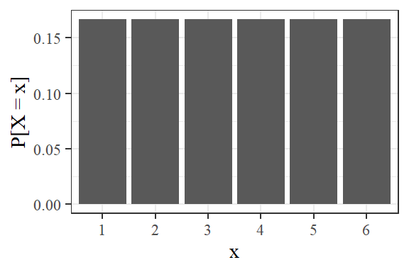

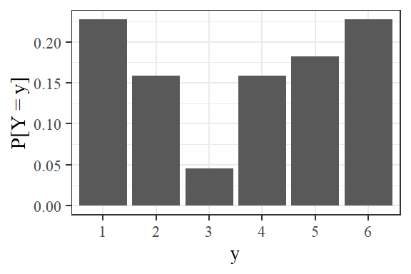

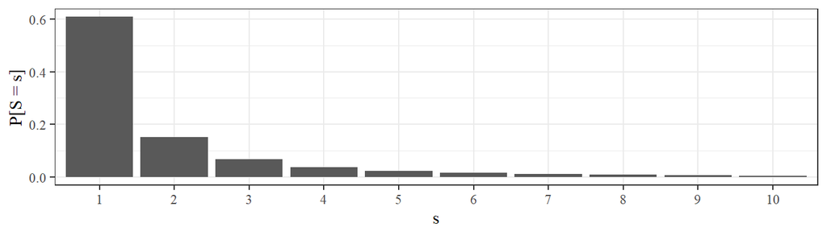

### Probability mass functions and cumulative distribution functions

The tool most often used to describe a discrete probability distribution is the *probability mass function*.

Properties of a mathematically valid probability mass function:

A probability mass function $f(x)$ gives probabilities of occurrence for individual values. Adding the appropriate values gives probabilities associated with the occurrence of multiple values.

Another way of specifying a discrete probability distribution is sometimes used.

Since (for discrete distributions) probabilities are calculated by summing values of $f(x)$,

$$F(x) = P[X \le x] = \sum\limits_{y \le x} f(y)$$

Properties of a mathematically valid cumulative distribution function:

### Summaries

Almost all of the devices for describing relative frequency (empirical) distributions in Ch. 3 have versions that can describe (theoretical) probability distributions.

### Special discrete distributions

Discrete probability distributions are sometimes developed from past experience with a particular physical phenomenon.

On the other hand, sometimes an easily manipulated set of mathematical assumptions having the potential to describe a variety of real situations can be put together.

One set of assumptions is that of independent identical success-failure trials where

Consider a variable
$$X = \text{ the number of successes in } n \text{ independent identical success-failure trials}$$

Examples that could follow a binomial($n, p$) distribution:

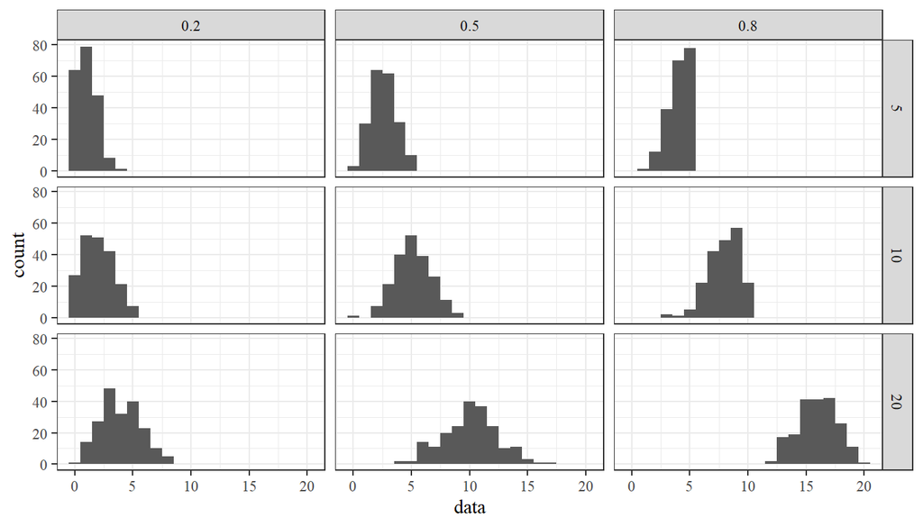

For $X$ a binomial($n, p$) random variable,
$$\begin{align*}
\mu &= \text{E}X = \sum\limits_{x = 0}^n x \frac{n!}{x!(n-x)!}p^x(1-p)^{n-x}) = np \\
\sigma^2 &= \text{Var}X = \sum\limits_{x = 0}^n (x-np)^2 \frac{n!}{x!(n-x)!}p^x(1-p)^{n-x}) = np(1-p)
\end{align*}$$

Consider a variable
$$X = \text{ the number of trials required to first obtain a success result }$$

Examples that could follow a geometric($p$) distribution:

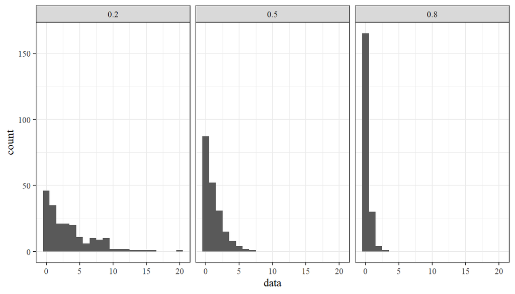

For $X$ a geometric($p$) random variable,
$$\begin{align*}
\mu &= \text{E}X = \sum\limits_{x = 1}^\infty x p(1-p)^{x-1} = \frac{1}{p} \\
\sigma^2 &= \text{Var}X = \sum\limits_{x = 1}^\infty \left(x-\frac{1}{p}\right)^2 p(1-p)^{x-1} = \frac{1-p}{p^2}
\end{align*}$$

Cdf derivation:

It’s often important to keep track of the total number of occurrences of some relatively rare phenomenon.

Consider a variable
$$X = \text{ the count of occurences of a phenomenon across a specified interval of time or space }$$

These occurrences must:

Examples that could follow a Poisson($\lambda$) distribution:

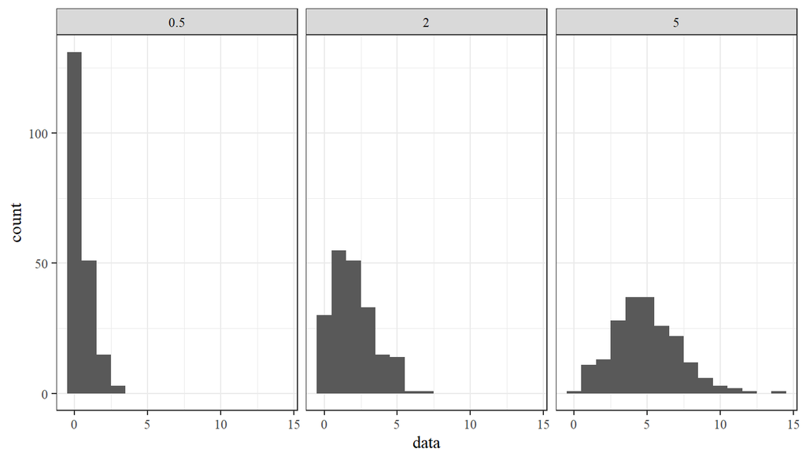

For $X$ a Poisson($\lambda$) random variable,
$$\begin{align*}
\mu &= \text{E}X = \sum\limits_{x = 0}^\infty x \frac{e^{-\lambda}\lambda^x}{x!} = \lambda \\
\sigma^2 &= \text{Var}X = \sum\limits_{x = 0}^\infty \left(x-\lambda\right)^2 \frac{e^{-\lambda}\lambda^x}{x!} = \lambda
\end{align*}$$

## Continuous random variables

It is often convenient to think of a random variable as having a whole (continuous) interval for its set of possible values.

The devices used to describe continuous probability distributions differ from those that describe discrete probability distributions.

Examples of continuous random variables:

### Probability density functions and cumulative distribution functions

A *probability density function (pdf)* is the continuous analogue of a discrete random variable’s probability mass function (pmf).

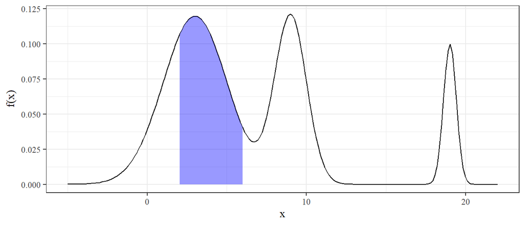

$F(x)$ is obtained from $f(x)$ by integration, and applying the fundamental theorem of calculus yields

$$\frac{d}{dx}F(x) = f(x).$$

That is, $f(x)$ is obtained from $F(x)$ by differentiation.

As with discrete random variables, $F$ has the following properties:

### Quantiles

**Recall:**

In terms of the cumulative distribution function (for a continuous random variable),

### Means and variances for continuous distributions

It is possible to summarize continuous probability distributions using

Why does $\text{E}(X^2) = \int\limits_{-\infty}^\infty x^2f(x) dx$?

For a linear function, $g(X) = aX + b$, where $a$ and $b$ are constants,

$\text{E}(aX + b)$

$\text{Var}(aX + b)$

$Z$ has mean $0$

$Z$ has variance (and standard deviation) $1$

### A special continuous distribution

Just as there are a number of useful discrete distributions commonly applied to engineering problems, there are a number of standard continuous probability distributions.

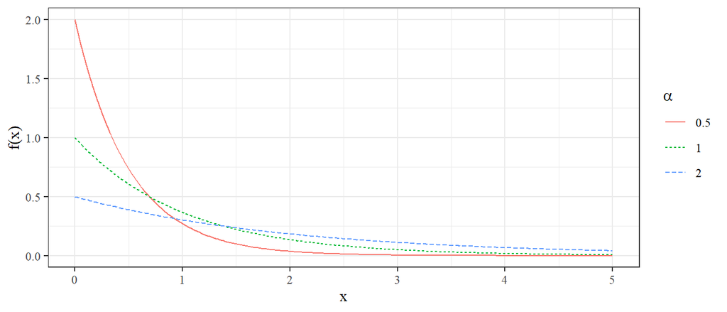

An $\text{Exp}(\alpha)$ random variable measures the waiting time until a specific event that has an equal chance of happening at any point in time.

Examples:

It is straightforward to show for $X \sim \text{Exp}(\alpha)$,

Further, $F(x)$ has a simple formulation:

### The Normal distribution

We have already seen the normal distribution as a “bell shaped” distribution, but we can formalize this.

A normal random variable is (often) a finite average of many repeated, independent, identical trials.

It is not obvious, but

The Calculus I methods of evaluating integrals via anti-differentiation will fail when it comes to normal densities. They do not have anti-derivatives that are expressible in terms of elementary functions.

The use of tables for evaluating normal probabilities depends on the following relationship. If $X \sim \text{Normal}(\mu, \sigma^2)$,
$$P[a \le X \le b] = \int\limits_a^b\frac{1}{\sqrt{2\pi\sigma^2}} e^{-(x - \mu)^2/{2\sigma^2}}dx = \int\limits_{(a- \mu)/\sigma}^{(b-\mu)/\sigma}\frac{1}{\sqrt{2\pi}} e^{-z^2/2}dz = P\left[\frac{a - \mu}{\sigma} \le Z \le \frac{b - \mu}{\sigma}\right]$$
where $Z \sim \text{Normal}(0, 1)$.

So, we can find probabilities for all normal distributions by tabulating probabilities for only the standard normal distribution. We will use a table of the **standard normal cumulative probability function**.

We can find standard normal quantiles by using the standard normal table in reverse.

## Joint distributions and independence (discrete)

Most applications of probability to engineering statistics involve not one but several random variables. In some cases, the application is intrinsically multivariate.

Even when a situation is univariate, samples larger than size $1$ are essentially always used in engineering applications. The $n$ data values in a sample are usually thought of as subject to chance and their simultaneous behavior must then be modeled.

This is actually a very broad and difficult subject, we will only cover a brief introduction to the topic: **jointly discrete random variables**.

### Joint distributions

For several discrete random variable, the device typically used to specify probabilities is a *joint probability function*. The two-variable version of this is defined.

Properties:

For the discrete case, it is useful to give $f(x,y)$ in a **table**.

### Marginal distributions

In a bivariate problem, one can add down columns in the (two-way) table of $f(x, y)$ to get values for the probability function of $X$, $f_X(x)$ and across rows in the same table to get values for the probability distribution of $Y$, $f_Y(y)$.

Getting marginal probability functions from joint probability functions begs the question whether the process can be reversed. **Can we find joint probability functions from marginal probability functions?**

### Conditional distributions

When working with several random variables, it is often useful to think about what is expected of one of the variables, given the values assumed by all others.

### Independence

Recall the following joint distribution:

**What do you notice?**

**Alternatively**, discrete random variables $X$ and $Y$ are independent if for all $x$ and $y$,

If $X$ and$Y$ are not only independent but also have the same marginal distribution, then they are **independent and identically distributed (iid)**.

## Functions of several random variables

We’ve now talked about ways to simultaneously model several random variables. An important engineering use of that material is in the analysis of system output that are functions of random inputs.

### Linear combinations

For engineering purposes, it often suffices to know the mean and variance for a function of several random variables, $U = g(X_1, X_2, \dots, X_n)$ (as opposed to knowing the whole distribution of $U$). When $g$ is **linear**, there are explicit functions.

A particularly important use of Proposition concerns $n$ iid random variables where each $a_i = \frac{1}{n}$.

We can find the mean and variance of the random variable

$$\overline{X} = \frac{1}{n} X_1 + \cdots \frac{1}{n}X_n = \frac{1}{n}\sum\limits_{i=1}^n X_i$$

as they relate to the population parameters $\mu = \text{E}X_i$ and $\sigma^2 = \text{Var}X_i$.

For independent variables $X_1, \dots, X_n$ with common mean $\mu$ and variance $\sigma^2$,

$\text{E}\overline{X} =$

$\text{Var}\overline{X} =$

### Central limit theorem

One of the most frequently used statistics in engineering applications is the sample mean. We can relate the mean and variance of the probability distribution of the sample mean to those of a single observation when an iid model is appropriate.

This is one of the **most important** results in statistics.

A plausible model for the pair of random variables $W_1, W_2$ is that they are independent, each with the marginal probability function

$$f(w) = \begin{cases} .1 & w = 0, 1, 2, \dots, 9 \\ 0 & \text{otherwise}\end{cases}$$

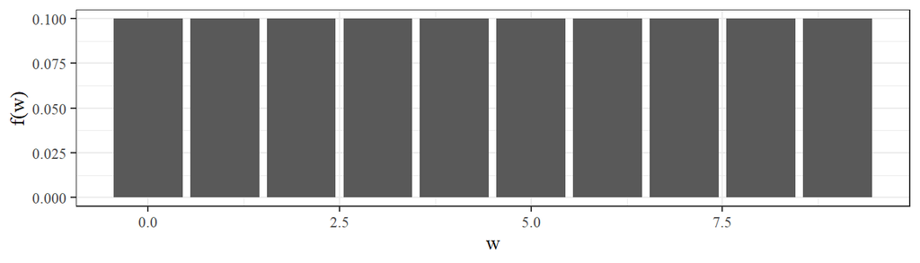

With $\text{E}W = 4.5$ and $\text{Var}W = 8.25$.

Using such a distribution, it is possible to see that $\overline{W} = \frac{1}{2}(W_1 + W_2)$ has probability distribution

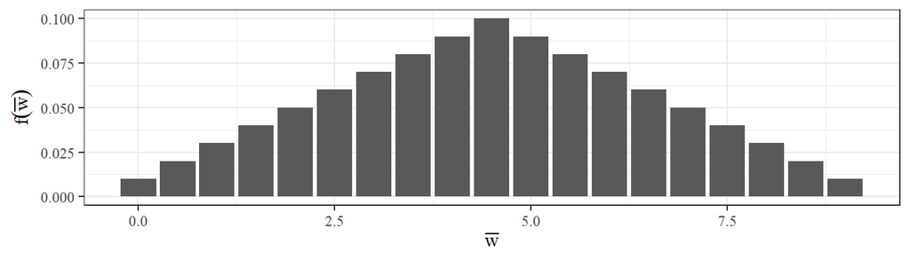